# STAT340 Discussion 7: the CLT and Confidence Intervals

Matej Popovski, Alex Holland, Brock Lunstrum, Zoe Weinstein

## XKCD comic

[figure not shown]

## Problem 1: Checking the CLT

The central limit theorem (or, at least the version of it that we saw in lecture) states that if $X_1,X_2,\dots$ are iid random variables with shared mean $\mu = \mathbb{E} X_1$ and variance $\sigma^2 = \operatorname{Var} X_1$, then as $n \rightarrow \infty$, the recentered, rescaled random variable
$$\frac{ \frac{1}{n} \sum_{i=1}^n X_i - \mu }{ \sqrt{\sigma^2/n} }$$
is well approximated by a standard normal.

Let’s explore what that looks like in practice (or, at least, in the practice of simulated data) by running an experiment.

We will generate $n$ draws from an exponential distribution, and take their sample mean.

We will repeat this experiment many times and plot the histogram of the sample means, and we’ll see that the plot looks more and more “normal” as we increase $n$.

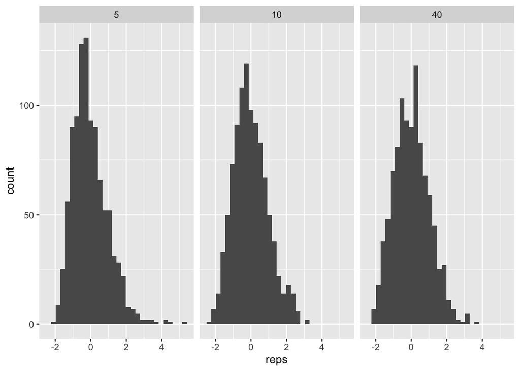

```r
require(ggplot2)
Nrep <- 1000
nvals <- c(5, 10, 40)
lambda <- 1 / 5
# True rate parameter in the exponential.
truemean <- 1 / lambda
# Mean of exp is 1/rate
truevar <- 1 / lambda**2
# var of exp is 1/rate^2.
# We will store our results in a data frame with columns
# reps : Each entry is a centered, scaled sample mean.
# n : the sample size (= 20, 50, 100)
nvec <- rep(nvals, each = Nrep)
reps <- rep(NA, Nrep * length(nvals))
results <- data.frame("n" = as.factor(nvec), "reps" = reps)
# Now let's run our experiment
for (n in nvals) {
  centered_scaled <- rep(NA, Nrep)
  for (i in 1:Nrep) {
    # Repeat expt Nrep times for this n value.
    sample <- rexp(n = n, rate = lambda)
    centered_scaled[i] <- (mean(sample) - truemean) / sqrt(truevar / n)
  }
  results[results$n == n, ]$reps <- centered_scaled
}
# Now let's plot, with one histogram for each of those n values.
pp <- ggplot(results, aes(x = reps))
pp <- pp + geom_histogram(aes())
pp <- pp + facet_wrap(~n)
pp
```

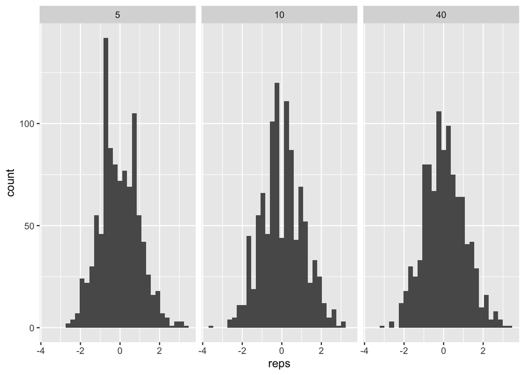

```r
# Change the distribution parameters and true statistics
Nrep <- 1000
nvals <- c(5, 10, 40)
lambda <- 5  # Rate parameter for Poisson distribution (mean and variance)

# True mean and variance for the Poisson distribution
truemean <- lambda
truevar <- lambda

# Repeat the remaining code as before
nvec <- rep(nvals, each = Nrep)
reps <- rep(NA, Nrep * length(nvals))
results <- data.frame("n" = as.factor(nvec), "reps" = reps)

# Simulation loop
for (n in nvals) {
  centered_scaled <- rep(NA, Nrep)
  for (i in 1:Nrep) {
    sample <- rpois(n = n, lambda = lambda)
    centered_scaled[i] <- (mean(sample) - truemean) / sqrt(truevar / n)
  }
  results[results$n == n, ]$reps <- centered_scaled
}

# Plotting the results
pp <- ggplot(results, aes(x = reps))
pp <- pp + geom_histogram(aes(), bins = 30)
pp <- pp + facet_wrap(~n)
pp
```

Try changing the distribution above from the Exponential to something else (e.g, Poisson or uniform). Alternatively, try playing around with the parameters (e.g., changing the rate parameter in the exponential). Don’t forget to update the true mean and true variance accordingly (feel free to look up the mean and variance of your distribution of choice on Wikipedia or in an introductory probability textbook).